# Task2 - Report

Chiara Laudani

02-10-2019

The task for this week is: "With one heading per county (Nordland, Troms and Finnmark), find out how many companies have been registered per month, per county, and make a plot of it.

Use the rvest package to scrape the data. This is possible since a specific search generates a unique url. On the web-page with the search results, please note that the html node for the “table” is quite useless as an initial search term for scraping the web page using rvest::html_nodes(). Use the html_nodes function twice, first with the xpath = “//table” specified, then with the html_nodes(“table”). Otherwise you will get plenty of “gibberish” to clean up afterwards. Still, there is a bit to do before the final data is ready".

The first thing to do is to load the HTML content from the URL of the ‘Brønnøysund Register Centre’‘s website and store it in a variable here called ’webpage’.

```
## List of 2
##  $ node:<externalptr>
##  $ doc :<externalptr>
##  - attr(*, "class")= chr [1:2] "xml_document" "xml_node"
```

The content is then cleaned up and saved as a table by applying the html_nodes() function twice, and the html_table() function once after that.

The table still needs to be cleaned since it has columns that are not needed, multiple empty rows, and cells containing ‘NA’ as a value. We also notice that in the ‘Announcement types’ column (called ‘X8’ for now) there is only one type we are really interested in, so we filter out the other one and then translate to English the value of the type we are interested in.

We now want to find out in which row the separators with the name of the county are located, so we use the which() and grepl() functions together to get that exact information for all three counties. We then change the names of the columns, and add a ‘county’ column which we fill completely with ‘NA’ for now.

A final clean up of the data is made before plotting: first we assign the correct county value to each row making use of the row indexes found earlier. We say that for every county, every row between that county’s index and the next county’s index-1, will get that county’s value assigned in the ‘county’ column. For the Finnmark county, the range is between its index and the last row in the table.

The rows with the county names are then removed, along with the columns with the enterprises’ number, and the announcement type. This is done because that information will not be useful when plotting the data. The format of the creation date is also changed to the “Date” format, and only the abbreviation of the corresponding month is kept. The day and year are removed because not influential on the plot’s outcome.

The data is then plotted using a bar chart and the dark theme provided in the ggplot2 package. The data is taken from the ‘data_col’ table where the number of enterpreises which registered in a specific month, are counted per each county. The abbreviations of the months are ordered chronologically - instead of alphabetically - and each county gets a different colour in the plot.

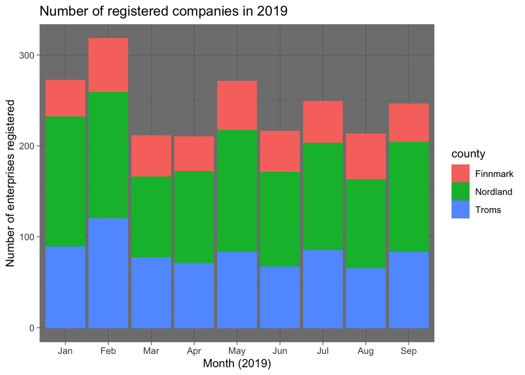